# Homework 4

STAT 757 – Section 1001  
Instructor: Colin Grudzien

## Due: 10/10/2019

## Instructions

> You may work with others on these problems but you must turn in your own work.  
> You may type your solutions in any way you like (LaTeX, Markdown, Office, etc…) as long as you present your work clearly and in an organized way.  
> **Whenever plotting:**
> - Include a copy of a short R script corresponding to your plot.
> - Your plot must be clearly labeled in all axes, legends, and the plot must include a clear title.
> - The plot must be sensible and easy to read.

## Problems

### Load the library “Faraway” in the R environment. Then proceed to analyze the following data sets in this library:

### Problem 1:

The dataset `teengamb` concerns a study of teenage gambling in Britain. Fit a regression model with the expenditure on gambling as the response and the sex, status, income and verbal score as predictors.

1. What percentage of variation in the response is explained by these predictors?
2. Which observation has the largest (positive) residual? Give the case number.
3. For all other predictors held constant, what would be the difference in predicted expenditure on gambling for a male compared to a female?
4. Which variables are statistically significant at the $5\%$ level?
5. Fit a model with just income as a predictor and use an F-test to compare it to the full model. Do we reject or fail to reject the null hypothesis?

### Solutions:

```r
library(faraway)
```

#### Problem 1.1

```r
lgamble <- lm(gamble ~ sex + status + income + verbal, data=teengamb)
gm_sum <- summary(lgamble)
gm_sum
```

```
##
## Call:
## lm(formula = gamble ~ sex + status + income + verbal, data = teengamb)
##
## Residuals:
##     Min      1Q  Median      3Q     Max
## -51.082 -11.320  -1.451   9.452  94.252
##
## Coefficients:
##              Estimate Std. Error t value Pr(>|t|)
## (Intercept)  22.55565   17.19680   1.312   0.1968
## sex         -22.11833    8.21111  -2.694   0.0101 *
## status        0.05223    0.28111   0.186   0.8535
## income        4.96198    1.02539   4.839 1.79e-05 ***
## verbal       -2.95949    2.17215  -1.362   0.1803
## ---
## Signif. codes:  0 '***' 0.001 '**' 0.01 '*' 0.05 '.' 0.1 ' ' 1
##
## Residual standard error: 22.69 on 42 degrees of freedom
## Multiple R-squared:  0.5267, Adjusted R-squared:  0.4816
## F-statistic: 11.69 on 4 and 42 DF,  p-value: 1.815e-06
```

Note that the percentage of variation explained is equal to the “Multiple $R^2$” coefficient in the model summary. Thus, we find the percentage of variation explained is equal to approximately .5267.

#### Problem 1.2 We can find the largest residual as follows:

```r
gm_res <- gm_sum$residuals
max(gm_res)
```

```
## [1] 94.25222
```

With the value in mind, we use the “match” function to find the appropriate index:

```r
match(max(gm_res),gm_res)
```

```
## [1] 24
```

Thus the observation with the largest positive redsidual is number 24.

#### Problem 1.3

In this case, as “sex” is a binary variable in the data with 0=male, 1=female, we say that for all other explanatory variables held equal, the difference in the response for the expected expenditure on gambling is the coefficient for $\boldsymbol{\beta}_{sex}=-22.11833$ found in the summary.

#### Problem 1.4

From the model summary, we see that each of `sex` and `income` are significant at $5\%$.

#### Problem 1.5

We will fit a model only in terms of income,

```r
income_lmod <- lm(gamble ~ income, data=teengamb)
```

and test this model versus the full model in an F-test with the ANOVA function:

```r
anova(lgamble, income_lmod)
```

```
## Analysis of Variance Table
##
## Model 1: gamble ~ sex + status + income + verbal
## Model 2: gamble ~ income
##   Res.Df   RSS Df Sum of Sq      F  Pr(>F)
## 1     42 21624
## 2     45 28009 -3   -6384.8 4.1338 0.01177 *
## ---
## Signif. codes:  0 '***' 0.001 '**' 0.01 '*' 0.05 '.' 0.1 ' ' 1
```

Here we see that we can reject the null with $5\%$ significance.

### Problem 2:

The dataset `uswages` is drawn as a sample from the Current Population Survey in 1988. Fit a model with weekly wages as the response and years of education and experience as predictors.

1. Report and give a simple interpretation to the regression coefficients for years of education, experience and the intercept.
2. Now fit the same model but with log-scale weekly wages. Give an interpretation to the regression coefficient for years of education, experience and the intercept in terms of the original scale for the response. Which scale for the response variable in the linear model seems more reasonable?
3. Finally, compute the confidence intervals and joint confidence regions for both models and discuss the uncertainty in the parameters.

### Solutions:

#### Problem 2.1

We start by fitting the model for weekly wages as the response and years of education and experience as explanatory variables, i.e.,

```r
lwages <- lm(wage ~ educ + exper, data=uswages)
lwage_sum <- summary(lwages)
lwage_sum
```

```
##
## Call:
## lm(formula = wage ~ educ + exper, data = uswages)
##
## Residuals:
##     Min      1Q  Median      3Q     Max
## -1018.2  -237.9   -50.9   149.9  7228.6
##
## Coefficients:
##              Estimate Std. Error t value Pr(>|t|)
## (Intercept) -242.7994    50.6816  -4.791 1.78e-06 ***
## educ          51.1753     3.3419  15.313  < 2e-16 ***
## exper          9.7748     0.7506  13.023  < 2e-16 ***
## ---
## Signif. codes:  0 '***' 0.001 '**' 0.01 '*' 0.05 '.' 0.1 ' ' 1
##
## Residual standard error: 427.9 on 1997 degrees of freedom
## Multiple R-squared:  0.1351, Adjusted R-squared:  0.1343
## F-statistic:   156 on 2 and 1997 DF,  p-value: < 2.2e-16
```

According to this model fit, we say that the impact of education is much higher than the impact of experience in explaning the weeky wages. Particularly, a one year increase in a person’s eduction would correspond to about 51 dollars of increased weekly wages versus one year of experience giving only about 9.77 dollars of increased weekly wages, on average.

#### Problem 2.2

Now we fit a similar model, but take the log of the response variable to fit our relationship. That is,

```r
log_wage_m <- lm(log(wage) ~ educ + exper, data=uswages)
log_wage_sum <- summary(log_wage_m)
log_wage_sum
```

```
##
## Call:
## lm(formula = log(wage) ~ educ + exper, data = uswages)
##
## Residuals:
##     Min      1Q  Median      3Q     Max
## -2.7533 -0.3495  0.1068  0.4381  3.5699
##
## Coefficients:
##             Estimate Std. Error t value Pr(>|t|)
## (Intercept) 4.650319   0.078354   59.35   <2e-16 ***
## educ        0.090506   0.005167   17.52   <2e-16 ***
## exper       0.018079   0.001160   15.58   <2e-16 ***
## ---
## Signif. codes:  0 '***' 0.001 '**' 0.01 '*' 0.05 '.' 0.1 ' ' 1
##
## Residual standard error: 0.6615 on 1997 degrees of freedom
## Multiple R-squared:  0.1749, Adjusted R-squared:  0.174
## F-statistic: 211.6 on 2 and 1997 DF,  p-value: < 2.2e-16
```

In this case, education has a stronger impact than experience on the logged weekly wages, similarly to the case with the linear scale for the weekly wages. However, we note that due to the log scale in the response variables, the form of the regression function back in linear scale takes the form,
$$\begin{align}
& \log(Y_{wages}) = \beta_0 + \beta_{educ} X_{educ} + \beta_{exper}X_{exper} + \epsilon \\
\Leftrightarrow & Y_{wages} = e^{\beta_0} * e^{\left( \beta_{educ} X_{educ} + \beta_{exper}X_{exper}\right)}*e^\epsilon
\end{align}$$
Therefore, a change of $d_x$ in education or experience corresponds to an increase of approximately $e^{0.09 d_x}$ for education or $e^{0.018 d_x}$ respectively.

This interpretation can be seen as more natural due to the differences in the standard error for the two models with the linear scale being much higher. As well, for zero years of experience and zero years of education, the linear scale will give negative weekly wages which is “unphysical” for the problem. Indeed, zero years of education and experience are in the scope of this model,

```r
summary(uswages)
```

```
##       wage              educ           exper            race
##  Min.   :  50.39   Min.   : 0.00   Min.   :-2.00   Min.   :0.000
##  1st Qu.: 308.64   1st Qu.:12.00   1st Qu.: 8.00   1st Qu.:0.000
##  Median : 522.32   Median :12.00   Median :15.00   Median :0.000
##  Mean   : 608.12   Mean   :13.11   Mean   :18.41   Mean   :0.078
##  3rd Qu.: 783.48   3rd Qu.:16.00   3rd Qu.:27.00   3rd Qu.:0.000
##  Max.   :7716.05   Max.   :18.00   Max.   :59.00   Max.   :1.000
##       smsa             ne              mw               so
##  Min.   :0.000   Min.   :0.000   Min.   :0.0000   Min.   :0.0000
##  1st Qu.:1.000   1st Qu.:0.000   1st Qu.:0.0000   1st Qu.:0.0000
##  Median :1.000   Median :0.000   Median :0.0000   Median :0.0000
##  Mean   :0.756   Mean   :0.229   Mean   :0.2485   Mean   :0.3125
##  3rd Qu.:1.000   3rd Qu.:0.000   3rd Qu.:0.0000   3rd Qu.:1.0000
##  Max.   :1.000   Max.   :1.000   Max.   :1.0000   Max.   :1.0000
##        we             pt
##  Min.   :0.00   Min.   :0.0000
##  1st Qu.:0.00   1st Qu.:0.0000
##  Median :0.00   Median :0.0000
##  Mean   :0.21   Mean   :0.0925
##  3rd Qu.:0.00   3rd Qu.:0.0000
##  Max.   :1.00   Max.   :1.0000
```

though we should believe that there are some errors in the data due to the negative years of experience.

#### Problem 2.3

We find the univariate confidence intervals of the two models as,

```r
confint(lwages)
```

```
##                   2.5 %     97.5 %
## (Intercept) -342.193750 -143.40507
## educ          44.621241   57.72929
## exper          8.302735   11.24680
```

```r
confint(log_wage_m)
```

```
##                  2.5 %     97.5 %
## (Intercept) 4.49665511 4.80398300
## educ        0.08037374 0.10063882
## exper       0.01580278 0.02035432
```

We will plot the joint confidence regions from the two models as follows.

In the below, we plot the joint confidence region for education and experience for the linear scale model:

```r
require(ellipse)
```

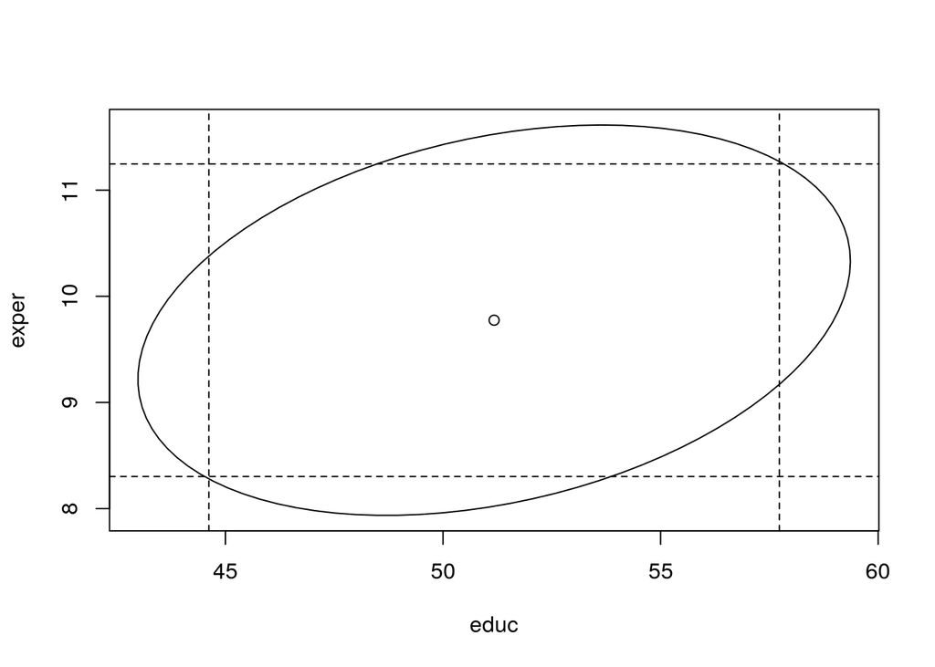

```r
plot(ellipse(lwages,c(2,3)),type="l")
points(coef(lwages)[2], coef(lwages)[3])
abline(v=confint(lwages)[2,],lty=2)
abline(h=confint(lwages)[3,],lty=2)
```

Here, we plot the joint confidence region for education and experience for the log scale model:

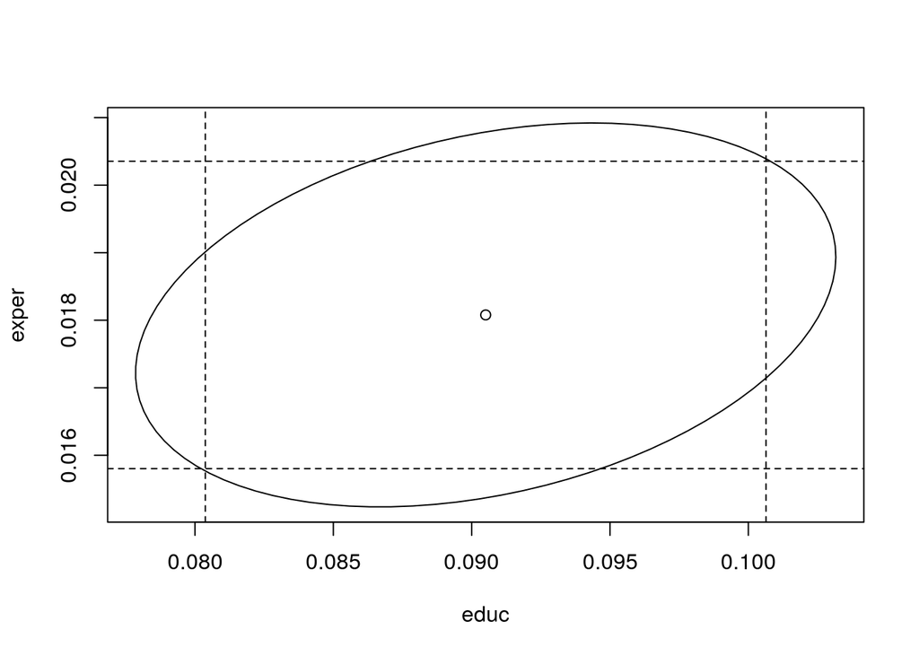

```r
require(ellipse)
plot(ellipse(log_wage_m,c(2,3)),type="l")
points(coef(log_wage_m)[2], coef(log_wage_m)[3])
abline(v=confint(log_wage_m)[2,],lty=2)
abline(h=confint(log_wage_m)[3,],lty=2)
```

Generally speaking, we see that there is far less uncertainty present in the parameters for the log-scale model, though this is especially so for the intercept term.

### Problem 3:

The dataset `prostate` comes from a study on 97 men with prostate cancer who were due to receive a radical prostatectomy. Fit a model with `lpsa` as the response and `lcavol` as the predictor. Record the residual standard error and the $R^2$ . Now add `lweight`, `svi`, `lbph`, `age`, `lcp`, `pgg45` and `gleason` to the model one at a time. For each model record the residual standard error and the $R^2$. For credit you should:

1. Plot the trends in these two statistics.
2. Discuss what you notice about the trends as we add more predictors to the model.

### Solutions:

We will fit a model for “lpsa” as a response variable, and “lcavol” as the explanatory only variable, record $R^2$ and then introduce the explanatory variables “lweight”, “svi”, “lbph”, “age”, “lcp”, “pgg45” and “gleason” one at a time, recording these models’ $R^2$ values.

We note that we will create 8 different models, and create a vector for storage of the 8 residual standard error values and the 8 $R^2$ values:

```r
Rstd_err_storage <- c(0,0,0,0,0,0,0,0)
Rsqr_storage <- c(0,0,0,0,0,0,0,0)
```

Then we assemble the models and store the values

```r
tmp <- summary(lm(lpsa ~ lcavol, data = prostate))
Rstd_err_storage[1] <- tmp$sigma
Rsqr_storage[1] <- tmp$r.squared

tmp <- summary(lm(lpsa ~ lcavol + lweight, data = prostate))
Rstd_err_storage[2] <- tmp$sigma
Rsqr_storage[2] <- tmp$r.squared

tmp <- summary(lm(lpsa ~ lcavol + lweight + svi, data = prostate))
Rstd_err_storage[3] <- tmp$sigma
Rsqr_storage[3] <- tmp$r.squared

tmp <- summary(lm(lpsa ~ lcavol + lweight + svi + lbph, data = prostate))
Rstd_err_storage[4] <- tmp$sigma
Rsqr_storage[4] <- tmp$r.squared

tmp <- summary(lm(lpsa ~ lcavol + lweight + svi + lbph + age, data = prostate))
Rstd_err_storage[5] <- tmp$sigma
Rsqr_storage[5] <- tmp$r.squared

tmp <- summary(lm(lpsa ~ lcavol + lweight + svi + lbph + age + lcp, data = prostate))
Rstd_err_storage[6] <- tmp$sigma
Rsqr_storage[6] <- tmp$r.squared

tmp <- summary(lm(lpsa ~ lcavol + lweight + svi + lbph + age + lcp + pgg45, data = prostate))
Rstd_err_storage[7] <- tmp$sigma
Rsqr_storage[7] <- tmp$r.squared

tmp <- summary(lm(lpsa ~ lcavol + lweight + svi + lbph + age + lcp + pgg45 + gleason, data = prostate))
Rstd_err_storage[8] <- tmp$sigma
Rsqr_storage[8] <- tmp$r.squared
```

#### Problem 3.1

We load “ggplot2”

```r
library(ggplot2)
```

and create a dataframe for plotting

```r
plt_range <- c(1,2,3,4,5,6,7,8)
prost_analysis <- data.frame(plt_range, Rstd_err_storage, Rsqr_storage)
```

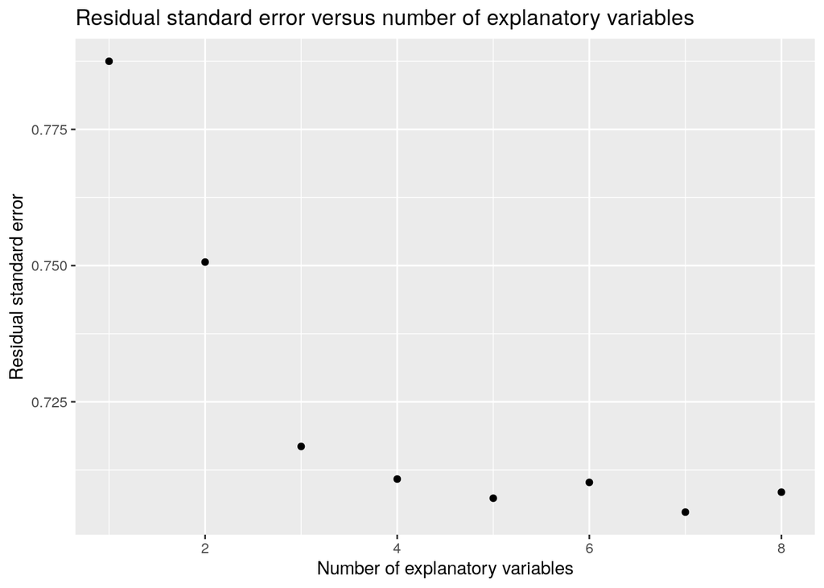

```r
ggplot(data=prost_analysis, aes(x=plt_range, y=Rstd_err_storage)) + geom_point() + labs(
   x = "Number of explanatory variables",
   y = "Residual standard error",
   title = "Residual standard error versus number of explanatory variables"
)
```

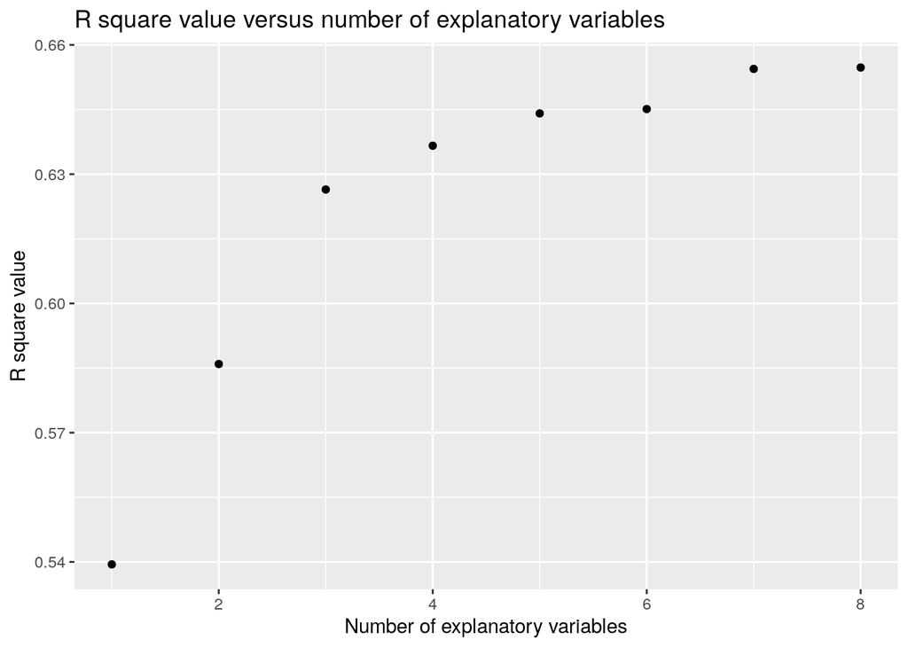

```r
ggplot(data=prost_analysis, aes(x=plt_range, y=Rsqr_storage)) + geom_point() + labs(
   x = "Number of explanatory variables",
   y = "R square value",
   title = "R square value versus number of explanatory variables"
)
```

#### Problem 3.2

We should notice that the $R^2$ value is monotonically increasing in the number of predictors. This would indicate that the model only improves when including more predictors. However, we have earlier discussed that there is an issue of overfitting when we include too many variables. We have not formally discussed why $R^2$ may not be the best way to select a model, but this would indicate that including more variables is always favored by $R^2$. On the other hand, the trend of the RSS is to go down as we include additional predictors. However, this is not always monotonic, as indicated by the profile.

### Problem 4:

Thirty samples of cheddar cheese were analyzed for their content of acetic acid, hydrogen sulfide and lactic acid. Each sample was tasted and scored by a panel of judges and the average taste score produced. Use the `cheddar` data to answer the following:

1. Fit a regression model with taste as the response and the three chemical contents as predictors. Report the values of the regression coefficients.
2. Compute the correlation between the fitted values and the response. Square it. Identify where this value appears in the regression output.
3. Fit the same regression model but without an intercept term. What is the value of $R^2$reported in the output? Compute a more reasonable measure of the good- ness of fit for this example.
4. How does the significance of the explanatory variables change between the model with and without intercept?

### Solutions:

#### Problem 4.1

We fit a regression model for taste as the response with the three chemicals as the explanatory variables, and report the coefficients:

```r
lm_cheddar <- lm(taste ~ Acetic + H2S + Lactic, data=cheddar)
coefficients(lm_cheddar)
```

```
## (Intercept)      Acetic         H2S      Lactic
## -28.8767696   0.3277413   3.9118411  19.6705434
```

#### Problem 4.2

We then compute the correlation of the fitted values and the response variables, squared:

```r
cor(lm_cheddar$fitted.values, cheddar$taste)^2
```

```
## [1] 0.6517747
```

We note that this is (approximately) equal to the value for multiple $R^2$ in the summary of lm_cheddar,

```r
summary(lm_cheddar)
```

```
##
## Call:
## lm(formula = taste ~ Acetic + H2S + Lactic, data = cheddar)
##
## Residuals:
##     Min      1Q  Median      3Q     Max
## -17.390  -6.612  -1.009   4.908  25.449
##
## Coefficients:
##             Estimate Std. Error t value Pr(>|t|)
## (Intercept) -28.8768    19.7354  -1.463  0.15540
## Acetic        0.3277     4.4598   0.073  0.94198
## H2S           3.9118     1.2484   3.133  0.00425 **
## Lactic       19.6705     8.6291   2.280  0.03108 *
## ---
## Signif. codes:  0 '***' 0.001 '**' 0.01 '*' 0.05 '.' 0.1 ' ' 1
##
## Residual standard error: 10.13 on 26 degrees of freedom
## Multiple R-squared:  0.6518, Adjusted R-squared:  0.6116
## F-statistic: 16.22 on 3 and 26 DF,  p-value: 3.81e-06
```

#### Problem 4.3

In order to supress the intercept term in the linear model, we use the following -1 command in the first entry

```r
lm_cheddar_no_intercept <- lm(taste ~ -1 + Acetic + H2S + Lactic, data=cheddar)
summary(lm_cheddar_no_intercept)
```

```
##
## Call:
## lm(formula = taste ~ -1 + Acetic + H2S + Lactic, data = cheddar)
##
## Residuals:
##      Min       1Q   Median       3Q      Max
## -15.4521  -6.5262  -0.6388   4.6811  28.4744
##
## Coefficients:
##        Estimate Std. Error t value Pr(>|t|)
## Acetic   -5.454      2.111  -2.583  0.01553 *
## H2S       4.576      1.187   3.854  0.00065 ***
## Lactic   19.127      8.801   2.173  0.03871 *
## ---
## Signif. codes:  0 '***' 0.001 '**' 0.01 '*' 0.05 '.' 0.1 ' ' 1
##
## Residual standard error: 10.34 on 27 degrees of freedom
## Multiple R-squared:  0.8877, Adjusted R-squared:  0.8752
## F-statistic: 71.15 on 3 and 27 DF,  p-value: 6.099e-13
```

We note that the value for $R^2$ is rather high in this case, and in particular, the language R will defer to the intercept version of the $R^2$ formula **even when there is no intercept**. For this reason, we need to compute this via the correlation squared defintion used earlier in part (b). I.e.,

```r
cor(lm_cheddar_no_intercept$fitted.values, cheddar$taste)^2
```

```
## [1] 0.6244075
```

We indeed find a more reasonable $R^2$ value.